# Small Islands, Big Impact: Why Earth Day Matters More Than Ever

Data Required to Track Progress

Author

Martina Regis

Published

April 2025

[figure not shown]

Photo credit: Recycled Mats

Every year on 22 April, the world observes World Earth Day, a global event dedicated to raising awareness about environmental protection and promoting sustainable practices. It serves as a crucial reminder of our collective responsibility to safeguard the planet for current and future generations. The theme of Earth Day this year is “Our Power, Our Planet.” The day’s events include local community initiatives, all aimed at driving action towards a healthier environment. The [World Economic Forum’s Global Risks Report 2025](https://www.weforum.org/publications/global-risks-report-2025/) finds that environmental risks make up half of the top 10 risks over the next 10 years.

# Earth Day Evolution

Originally focused on recycling, reduced energy consumption, and water conservation in the 1970s, Earth Day has evolved to address a much broader range of issues today, from mitigating climate change impacts to promoting environmental justice. For small island states, the importance of Earth Day is particularly pronounced, given their heightened vulnerability to these environmental challenges—perhaps making every day Earth Day.

Data plays a pivotal role in our fight for sustainability. By gathering and analyzing information on various environmental indicators, we can gain a deeper understanding of our progress, identify areas where we are falling short, and develop more effective strategies.

# Plastics - A Challenge of Our Times

Given its ubiquitous presence and substantial environmental consequences, this article centers on the issue of plastics. Plastic pollution has become as a major environmental crisis of our time, inflicting extensive harm on both natural systems and human well-being. Increasing public consciousness regarding this problem has shaped public sentiment and facilitated more robust policy responses.

Plastics are exceptionally versatile and adaptable, a quality that is hard to replicate. Their widespread benefits have led to a significant increase in their production in recent decades. These materials are lightweight, affordable, and can be used in numerous industrial applications, making them very valuable in today’s world. They play a key role in food preservation, building insulation, electronics manufacturing, and improving vehicle fuel efficiency, among many other uses. However, the enormous amount of plastic consumed by our society has created substantial challenges.

The [OECD’s Global Plastics Outlook](https://www.oecd.org/en/publications/global-plastics-outlook_de747aef-en/full-report.html) highlights the strain that the world’s insatiable appetite for plastics is placing on the environment. More than half of all plastic waste comes from single-use items and products with a lifespan of less than five years. Packaging accounts for the largest share of this waste (40 percent), followed by consumer goods (12 percent) and textiles (11 percent).

The ever-increasing production and use of plastics, particularly in items designed for short-term use, has led to a surge in waste and pollution from this ubiquitous material. Plastic pollution is now found in our water, air, and food, posing a growing threat to both environmental and human health. This pollution also undermines sustainable economic growth and human well-being.

In recent years, many regional governments have taken significant steps to curb plastic pollution, with single-use plastic bag bans being a common starting point. Policies aimed at banning single-use plastics are increasingly being adopted around the world, driven by insights from behavioral economics. These policies recognize that human behavior is often influenced by defaults, framing, and salience. For instance, a ban shifts the default option from using a plastic bag to bringing a reusable one, significantly increasing the likelihood of the latter. Similarly, charging a fee for plastic bags makes their use more salient, prompting consumers to consider the environmental cost of their choices.

# A Threat to SIDS Sustainability

The economic, ecological, and social consequences of single-use plastic pollution are far-reaching, particularly for marine life and small island states. Plastic waste negatively impacts economies by harming tourism, fisheries, and shipping industries. Marine life is severely affected, with ingestion, entanglement, and habitat destruction leading to decreased biodiversity and potential seafood contamination. Small island developing states (SIDS), despite contributing minimally to plastic pollution, face disproportionate impacts due to their reliance on marine resources and vulnerability to ocean currents that carry plastic waste to their shores.

The Caribbean, surrounded by coastline, is particularly vulnerable to the pervasive threat of plastic pollution. However, this problem is not unique to the region but affects every corner of the globe, with eight million tons of plastic entering the ocean each year.

# Charting Global Progress

Today, on Earth Day, it is important to explore the gains the world has made in one area - recycling and using plastics. How have countries fared? Have policies on recycling been effective? What more can be done?

Figure 1 illustrates global trends in plastic recycling rates. Comparing 2000 and 2019. Overall, the data reveals a general increase in recycling percentages across all regions. Notably, India and China demonstrated the most substantial improvements in recycling rates between 2000 and 2019, spearheading the gains. While progress has been made, the chart also highlights that recycling rates remain relatively low globally, emphasizing the continued need for more robust recycling programs and a shift towards reducing plastic consumption.

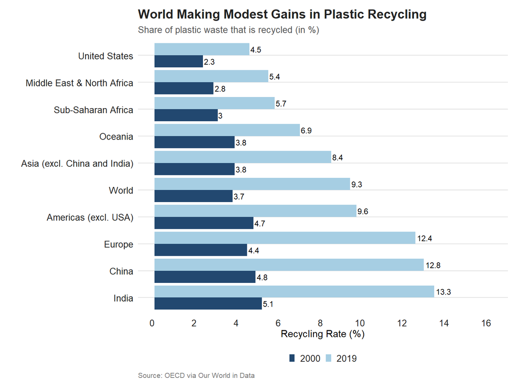

Figure 1: Recycling Trends

# Skyrocketing Production and Waste

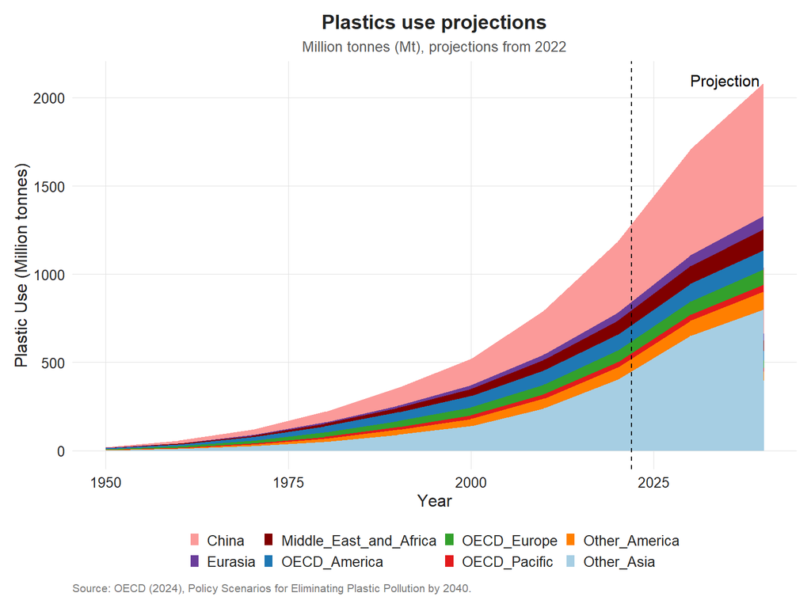

Figure 2: Plastic Projections under Baseline

The widespread use of plastics results in a significant carbon footprint from production, large volumes of waste, persistent pollution, and harm to wildlife and ecosystems when plastics leak into the environment. It also leads to substantial socio-economic costs due to the negative impacts of plastic litter on tourism and fisheries. Regarding plastic waste, it is estimated that 50 percent goes to landfills, 19 percent is incinerated, and only 9 percent is ultimately recycled. The remaining 22 percent is dumped in uncontrolled sites, burned in open pits, or ends up in rivers and oceans. Furthermore, plastics production contributes significantly to climate change, accounting for 3 to 4 percent of global greenhouse gas emissions. The increase in the production and use of primary plastics is a particular concern for climate change.

While waste management is expected to improve, these improvements will not keep pace with the growth in plastic waste (reaching 617 million tonnes in 2040, up from 360 million tonnes in 2020). This will result in 119 million tonnes of mismanaged waste in 2040, compared to 81 million tonnes in 2020. Leakage of plastics into the environment will also increase (from 20 million tonnes in 2020 to 30 million tonnes in 2040), exacerbating the adverse environmental and health impacts. The amount of plastic in rivers and oceans is projected to nearly double, from 152 million tonnes in 2020 to 300 million tonnes by 2040. The plastics lifecycle is projected to emit 2.8 gigatonnes of carbon dioxide equivalent (GtCO<sub>2</sub>) of greenhouse gas (GHG) emissions annually by 2040 (5% of global emissions), up from 1.8 Gt CO<sub>2</sub> in 2020, with the majority of these emissions coming from plastics production and processing.

# More Action Needed

While recent policy efforts in the region have concentrated on curbing the use of single-use plastic shopping bags, it’s crucial to acknowledge that these measures alone may be insufficient to address the scale of the plastic pollution crisis. Plastic shopping bags represent only a fraction of overall plastic consumption, with substantial volumes still utilized in global packaging, including in shipping, disposable water bottles, cosmetics and food packaging. The limited number of recycling facilities, the prevalence of indiscriminate dumping practices, and the lack of widespread public education regarding the dangers of plastic pollution further exacerbate the problem.

A **more holistic approach is needed**, encompassing a broader range of plastic products and prioritizing comprehensive waste management solutions and public awareness campaigns. We also need ways to track our progress.

The OECD report emphasizes that limited measures, such as focusing solely on improving waste management or implementing broad policies with weak enforcement, will likely fail to eliminate plastic pollution. Similarly, policies with strong enforcement only in developed economies will also be insufficient.

- Improving global waste management can decrease mismanaged waste to 9% by 2040 (compared to 23% in 2020). However, 54 million tonnes of plastic waste would still be mismanaged in 2040.
- Strong policy action only in advanced economies is unlikely to reduce mismanaged plastic waste below 2020 levels. Likewise, global policies with weak enforcement are unlikely to significantly change current trends.
- These limited approaches cannot reduce the production and use of new (primary) plastics below 2020 levels. Eliminating mismanaged plastic waste requires stringent measures to curb both production and demand on a global scale.

Implementing strong policies **across the entire lifecycle of plastics** in all countries can also prevent any increase in primary plastics production beyond 2020 levels and virtually eliminate plastic leakage into the environment by 2040.

- Stringent policies aimed at reducing production and demand (limiting total plastic use to 508 million tonnes in 2040), combined with policies to significantly increase recycling rates (quadrupling them to 42%), can ensure that all growth in plastics use is met through recycled plastics, rather than through new production.
- This comprehensive policy approach can nearly eliminate mismanaged waste by 2040 (reducing it by 97% compared to current trends) and prevent 74 million tonnes of plastics from polluting rivers and oceans.
- Strong policy action can lower annual plastics-related greenhouse gas emissions to 1.7 gigatonnes of carbon dioxide equivalent (GtCO2e) by 2040, significantly below the projected 2.8 GtCO<sub>2</sub> under current trends.

# Data - A Problem or Solution?

To effectively manage plastics, data is essential for pinpointing areas needing policy intervention and for aligning actions with global agreements made. Policies should be accompanied by data tracking to ensure objectives are met. We often suggest that climate action is affected by data limitations. Let’s no longer make data the problem but the solution by identifying ways to collect the onformation needed to improve policy-making.

Effective measurement enables effective management, allowing us to adjust our course and achieve our sustainability goals.

As we celebrate Earth Day on 22 April, it is the perfect opportunity to reflect on our planet’s health and how we can make a positive impact through sustainable living.